# Ortiz_Javier_GoogleApps

Javier Ortiz Montenegro

4 de enero de 2019

Parte del código está extraida de: “https://www.kaggle.com/q2000qfq/rate-predictor”, ejemplo drug001 y ejemplo XGBoost.

Los datos son distintas caracteristicas de un conjunto de apps de Google Play Store entre las que podemos encontrar la cantidad de descargas, el rating, la cantidad de reviews, a que categoría pertenecen, precio, edad objetivo etc. He considerado que era una base de datos interesante ya que la cantidad de apps que se lanzan al año es enorme y creo que podría ser interesante realizar una predicción de las descargas que va a tener una app antes de ser lanzada en funcion de a que categoría pertenece, la edad del publico objetivo, su precio, etc. Esto ayudaría a las empresas desarrolladoras de apps a una asignación eficiente de sus activos a los proyectos con mayor previsión.

Una vez realizada la introducción del dataset se procederá al tratamiento.

Se empieza cargando las librerías necesarias.

```r
library(dplyr)
library(tidyr)
library(xgboost)
require("caret")
require("randomForest")
require("gbm")
library(plotROC)
library(ggplot2)
```

Posteriormente se realiza la carga y tratamiento de los datos. Al realizar un “summary” de los datos cargados nos encontramos frente a varios problemas, algunos errores en valores imposibles (Rating de 19 cuando unicamente es de 1 a 5), una observación se ha introducido incorrectamente, NAs, practicamente todas las variables como factor, etc…

```r
#Carga de datos y revisión de los mismos.
apps.df = read.csv("googleplaystore.csv")
summary(apps.df)
```

```
##                                                 App
##  ROBLOX                                           :    9
##  CBS Sports App - Scores, News, Stats & Watch Live:    8
##  8 Ball Pool                                      :    7
##  Candy Crush Saga                                 :    7
##  Duolingo: Learn Languages Free                   :    7
##  ESPN                                             :    7
##  (Other)                                          :10796
##          Category        Rating          Reviews
##  FAMILY      :1972   Min.   : 1.000   0      : 596
##  GAME        :1144   1st Qu.: 4.000   1      : 272
##  TOOLS       : 843   Median : 4.300   2      : 214
##  MEDICAL     : 463   Mean   : 4.193   3      : 175
##  BUSINESS    : 460   3rd Qu.: 4.500   4      : 137
##  PRODUCTIVITY: 424   Max.   :19.000   5      : 108
##  (Other)     :5535   NA's   :1474     (Other):9339
##                  Size             Installs      Type           Price
##  Varies with device:1695   1,000,000+ :1579   0   :    1   0      :10040
##  11M               : 198   10,000,000+:1252   Free:10039   $0.99  :  148
##  12M               : 196   100,000+   :1169   NaN :    1   $2.99  :  129
##  14M               : 194   10,000+    :1054   Paid:  800   $1.99  :   73
##  13M               : 191   1,000+     : 907                $4.99  :   72
##  15M               : 184   5,000,000+ : 752                $3.99  :   63
##  (Other)           :8183   (Other)    :4128                (Other):  316
##          Content.Rating           Genres             Last.Updated
##                 :   1   Tools        : 842   August 3, 2018: 326
##  Adults only 18+:   3   Entertainment: 623   August 2, 2018: 304
##  Everyone       :8714   Education    : 549   July 31, 2018 : 294
##  Everyone 10+   : 414   Medical      : 463   August 1, 2018: 285
##  Mature 17+     : 499   Business     : 460   July 30, 2018 : 211
##  Teen           :1208   Productivity : 424   July 25, 2018 : 164
##  Unrated        :   2   (Other)      :7480   (Other)       :9257
##              Current.Ver               Android.Ver
##  Varies with device:1459   4.1 and up        :2451
##  1.0               : 809   4.0.3 and up      :1501
##  1.1               : 264   4.0 and up        :1375
##  1.2               : 178   Varies with device:1362
##  2.0               : 151   4.4 and up        : 980
##  1.3               : 145   2.3 and up        : 652
##  (Other)           :7835   (Other)           :2520
```

```r
str(apps.df)
```

```
## 'data.frame':    10841 obs. of  13 variables:
##  $ App           : Factor w/ 9660 levels "- Free Comics - Comic Apps",..: 7229 2563 8998 8113 7294 7125 8171 5589 4948 5826 ...
##  $ Category      : Factor w/ 34 levels "1.9","ART_AND_DESIGN",..: 2 2 2 2 2 2 2 2 2 2 ...
##  $ Rating        : num  4.1 3.9 4.7 4.5 4.3 4.4 3.8 4.1 4.4 4.7 ...
##  $ Reviews       : Factor w/ 6002 levels "0","1","10","100",..: 1183 5924 5681 1947 5924 1310 1464 3385 816 485 ...
##  $ Size          : Factor w/ 462 levels "1,000+","1.0M",..: 55 30 368 102 64 222 55 118 146 120 ...
##  $ Installs      : Factor w/ 22 levels "0","0+","1,000,000,000+",..: 8 20 13 16 11 17 17 4 4 8 ...
##  $ Type          : Factor w/ 4 levels "0","Free","NaN",..: 2 2 2 2 2 2 2 2 2 2 ...
##  $ Price         : Factor w/ 93 levels "$0.99","$1.00",..: 92 92 92 92 92 92 92 92 92 92 ...
##  $ Content.Rating: Factor w/ 7 levels "","Adults only 18+",..: 3 3 3 6 3 3 3 3 3 3 ...
##  $ Genres        : Factor w/ 120 levels "Action","Action;Action & Adventure",..: 10 13 10 10 12 10 10 10 10 12 ...
##  $ Last.Updated  : Factor w/ 1378 levels "1.0.19","April 1, 2016",..: 562 482 117 825 757 901 76 726 1317 670 ...
##  $ Current.Ver   : Factor w/ 2834 levels "","0.0.0.2","0.0.1",..: 121 1020 466 2827 279 115 279 2393 1457 1431 ...
##  $ Android.Ver   : Factor w/ 35 levels "","1.0 and up",..: 17 17 17 20 22 10 17 20 12 17 ...
```

```r
#Tratamiento de valores atipicos, NA y duplicados.
apps.df$Installs[apps.df$Installs == "Free" ] = NA
apps.df$Rating[apps.df$Rating == 19] = NA
apps.df$Size[apps.df$Size == "Varies with device"] = NA
apps.df$Content.Rating[apps.df$Content.Rating == "Unrated" | apps.df$Content.Rating == "Adults only 18+"] = NA
apps.df = mutate(apps.df[,-c(10:13)]) %>% na.omit %>% droplevels() #En esta línea elimino las ultimas columnas del dataset ya que corresponden a la versión de la app, de android y la ultima vez actualizados, datos que me parecen poco importantes para la predicción de la cantidad de descargas.
apps.df = apps.df[!duplicated(apps.df),]

#Tratamiento de Reviews pasando de factor a numérico.
apps.df$Reviews = as.numeric(as.character(apps.df$Reviews))

#Tratamiento del tamaño eliminando las letras del factor para poder transformar a numérico.
apps.df$Size = as.character(apps.df$Size)
size_express_mb <- "[0-9]+[[:punct:]]?[0-9]*M"
size_express_kb <- "[0-9]+[[:punct:]]?[0-9]*k"

index_mb <- grep(apps.df$Size,pattern = size_express_mb)
mb.match = regexpr(apps.df$Size, pattern = size_express_mb)
mb = regmatches(apps.df$Size,mb.match)

mb1 <- substr(mb, 1,nchar(mb) - 1)
mb1 <- as.numeric(mb1)*1000
apps.df$Size[index_mb] <- mb1

index_kb <- grep(apps.df$Size,pattern = size_express_kb)
kb.match = regexpr(apps.df$Size, pattern = size_express_kb)
kb = regmatches(apps.df$Size,kb.match)

kb1 <- substr(kb, 1,nchar(kb) - 1)
kb1 <- as.numeric(kb1)
apps.df$Size[index_kb] <- kb1
apps.df$Size = as.numeric(apps.df$Size)

# Tratamiento de la variable Install eliminando el símbolo "+" y ",".

apps.df$Installs = as.character(apps.df$Installs)
apps.df$Installs = substr(apps.df$Installs, 1, nchar(apps.df$Installs)-1)
apps.df$Installs = gsub(",", "", c(apps.df$Installs))
apps.df$Installs = as.numeric(apps.df$Installs)

#Tratamiento de la variable Price eliminando el símbolo "$".

apps.df$Price = as.character(apps.df$Price)
apps.df$Price = substr(apps.df$Price, 2, nchar(apps.df$Price))
apps.df$Price[apps.df$Price == ""] = 0
apps.df$Price = as.numeric(apps.df$Price)

#Comprobación de los datos.
summary(apps.df)
```

```
##                   App                  Category        Rating
##  ROBLOX             :   9   FAMILY         :1591   Min.   :1.000
##  8 Ball Pool        :   7   GAME           : 959   1st Qu.:4.000
##  Bubble Shooter     :   6   TOOLS          : 632   Median :4.300
##  Helix Jump         :   6   PERSONALIZATION: 279   Mean   :4.171
##  Zombie Catchers    :   6   MEDICAL        : 277   3rd Qu.:4.500
##  Angry Birds Classic:   5   LIFESTYLE      : 273   Max.   :5.000
##  (Other)            :7380   (Other)        :3408
##     Reviews              Size             Installs           Type
##  Min.   :       1   Min.   :     8.5   Min.   :1.000e+00   Free:6872
##  1st Qu.:      99   1st Qu.:  5100.0   1st Qu.:1.000e+04   Paid: 547
##  Median :    2066   Median : 14000.0   Median :1.000e+05
##  Mean   :  278924   Mean   : 22752.1   Mean   :7.826e+06
##  3rd Qu.:   36868   3rd Qu.: 33000.0   3rd Qu.:1.000e+06
##  Max.   :44893888   Max.   :100000.0   Max.   :1.000e+09
##
##      Price              Content.Rating
##  Min.   :  0.000   Everyone    :5956
##  1st Qu.:  0.000   Everyone 10+: 299
##  Median :  0.000   Mature 17+  : 332
##  Mean   :  1.117   Teen        : 832
##  3rd Qu.:  0.000
##  Max.   :400.000
##
```

```r
str(apps.df)
```

```
## 'data.frame':    7419 obs. of  9 variables:
##  $ App           : Factor w/ 7026 levels "- Free Comics - Comic Apps",..: 5233 1845 6564 5899 5278 5162 5938 4005 3538 4183 ...
##  $ Category      : Factor w/ 33 levels "ART_AND_DESIGN",..: 1 1 1 1 1 1 1 1 1 1 ...
##  $ Rating        : num  4.1 3.9 4.7 4.5 4.3 4.4 3.8 4.1 4.4 4.7 ...
##  $ Reviews       : num  159 967 87510 215644 967 ...
##  $ Size          : num  19000 14000 8700 25000 2800 5600 19000 29000 33000 3100 ...
##  $ Installs      : num  1e+04 5e+05 5e+06 5e+07 1e+05 5e+04 5e+04 1e+06 1e+06 1e+04 ...
##  $ Type          : Factor w/ 2 levels "Free","Paid": 1 1 1 1 1 1 1 1 1 1 ...
##  $ Price         : num  0 0 0 0 0 0 0 0 0 0 ...
##  $ Content.Rating: Factor w/ 4 levels "Everyone","Everyone 10+",..: 1 1 1 4 1 1 1 1 1 1 ...
##  - attr(*, "na.action")= 'omit' Named int  24 38 43 53 68 69 74 86 89 90 ...
##   ..- attr(*, "names")= chr  "24" "38" "43" "53" ...
```

Se separan los datos en train/validation/test una vez tratados.

```r
#Definimos una semilla para que el ejercicio sea reproducible
set.seed(2019)
# Se separa de la siguiente manera: 60% a train, 20% a validate y 20% a test
inTraining <- createDataPartition(apps.df$Installs, p=0.6, list=FALSE)
training.set <- apps.df[inTraining,]
Totalvalidation.set <- apps.df[-inTraining,]
# Ahora creamos una nueva partición del 40% de los datos, 20% a testing y 20% a validation
inValidation <- createDataPartition(Totalvalidation.set$Installs, p=0.5, list=FALSE)
testing.set <- Totalvalidation.set[inValidation,]
validation.set <- Totalvalidation.set[-inValidation,]

#Para el tuning y la comparación de modelos se usaran los datos de "dataset" y "validation".
dataset <- training.set
validation <- validation.set
test <- testing.set

# El modelo final usara todos los datos. "Dataset" y "validation" agrupados en "total" y "test".
total <- rbind(dataset, validation)
```

Se pasa a definir los parametros de control y el grid para realizar el tuning de los distintos modelos a comparar.

```r
set.seed(2019)
fitControl <- trainControl(method = 'cv', number = 5, summaryFunction=defaultSummary)


#El primer Grid es el de boosting.
gbmGrid <-  expand.grid(interaction.depth = c(1,4,7,10),
                        n.trees = c(500, 1000, 2000),
                        shrinkage = c(.005, .02,.05),
                        n.minobsinnode = 10)



#En segundo lugar XGBoost.
tuneGridXGB <- expand.grid(
  nrounds=c(350),
  max_depth = c(2, 4, 6, 8),
  eta = c(0.05, 0.1),
  gamma = c(0.01),
  colsample_bytree = c(0.75),
  subsample = c(0.50),
  min_child_weight = c(0))

#Por ultimo definimos el de Random Forest.
#mtry max:
ncol(apps.df)-1
```

```
## [1] 8
```

```r
rfGrid <-  expand.grid(mtry = c(1,2,3,4,6,8))
```

Empezamos la comparación con el modelo boosting.

```r
set.seed(2019)
### Gradient boosting machine algorithm. ###
fit.gbm <- train(Installs~. -App, data=dataset, method = 'gbm', trControl=fitControl, tuneGrid=gbmGrid, metric='RMSE')
```

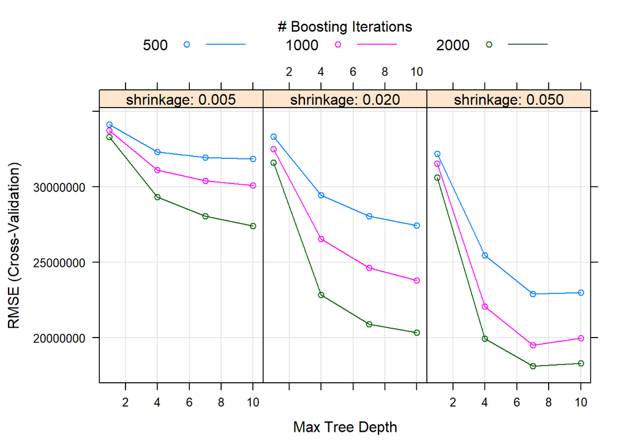

```r
plot(fit.gbm)
```

```r
#Como se puede ver en el gráfico el mejor "tune" corresponde a un shrinkage de 0.05, 2000 arboles e "interaction depth"" de 7
fit.gbm$bestTune
```

```
##    n.trees interaction.depth shrinkage n.minobsinnode
## 33    2000                 7      0.05             10
```

```r
res_gbm <- fit.gbm$results
RMSE_gbm <- subset(res_gbm[5])
# CV con mejor "tune"
BCV.RMSE = min(RMSE_gbm)

boost.caret.pred <- predict(fit.gbm,validation)
B.RMSE = (mean((boost.caret.pred - validation$Installs)^2))^0.5
```

En segundo lugar XGBoosting.

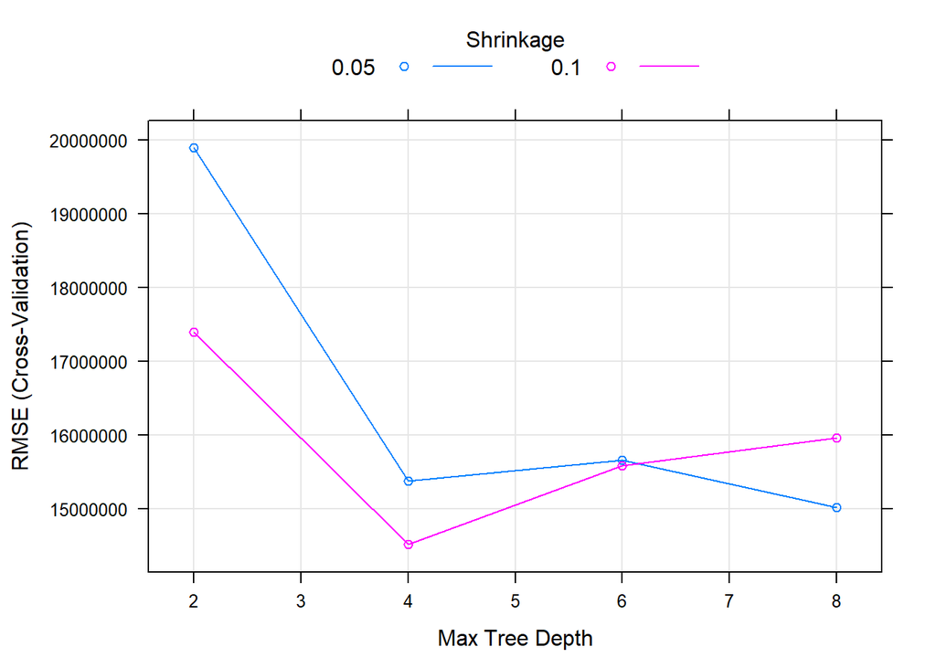

```r
set.seed(2019)
### EXtreme Gradient boosting algorithm. ###
fit.gbmx <- train(Installs~. -App, data=dataset, method = 'xgbTree', trControl=fitControl, tuneGrid=tuneGridXGB, metric='RMSE')

plot(fit.gbmx)
```

```r
#Se muestran abajo los parámetros del mejor "tune" que se puede apreciar en la gráfica.
fit.gbmx$bestTune
```

```
##   nrounds max_depth eta gamma colsample_bytree min_child_weight subsample
## 6     350         4 0.1  0.01             0.75                0       0.5
```

```r
res_gbmx <- fit.gbmx$results
RMSE_gbmx <- subset(res_gbmx[8])
# CV con mejor "tune"
XBCV.RMSE = min(RMSE_gbmx)

xboost.caret.pred <- predict(fit.gbmx,validation)
XB.RMSE = (mean((xboost.caret.pred - validation$Installs)^2))^0.5
```

Por último Random Forest.

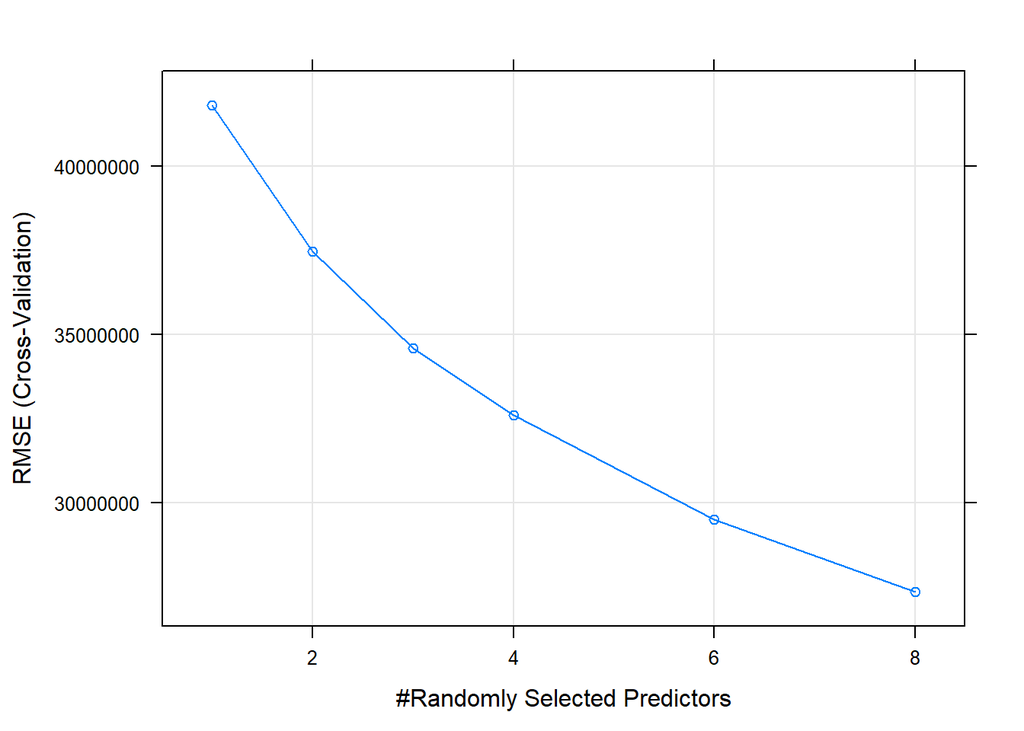

```r
set.seed(2019)
### Random Forest algorithm. ###
fit.rf <- train(Installs~. -App, data=dataset, method = 'rf', trControl=fitControl, tuneGrid=rfGrid, metric='RMSE')

plot(fit.rf)
```

```r
#Como se puede ver en la gráfica el número óptimo de predictores seleccionados es 8.

res_rf <- fit.rf$results
RMSE_rf <- subset(res_rf[2])

# CV con mejor "tune"
RFCV.RMSE = min(RMSE_rf)


rf.caret.pred <- predict(fit.rf,validation)
RF.RMSE = (mean((rf.caret.pred - validation$Installs)^2))^0.5
```

Resultados RMSE

|  | Boosting | XGB | Random Forest |
| --- | --- | --- | --- |
| CV | 18123240 | 14514727 | 27336883 |
| Validation set | 21712259 | 13343429 | 27337803 |

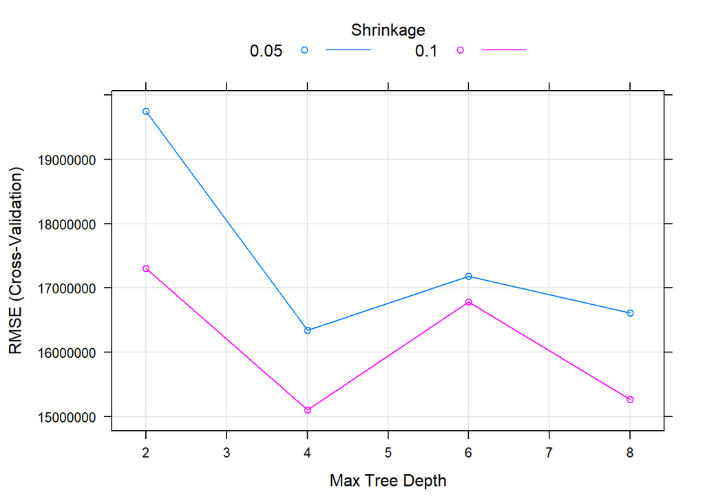

```r
set.seed(2019)
fit.xgb_total <- train(Installs~. -App, data=total, method = 'xgbTree', trControl=fitControl, tuneGrid=tuneGridXGB, metric='RMSE')
plot(fit.xgb_total)
```

```r
fit.xgb_total$bestTune
```

```
##   nrounds max_depth eta gamma colsample_bytree min_child_weight subsample
## 6     350         4 0.1  0.01             0.75                0       0.5
```

```r
res_xgb_total <- fit.xgb_total$results
RMSE_xgb_total <- subset(res_xgb_total[8])
# CV con mejor "tune"
XBCV_T.RMSE = min(RMSE_xgb_total)

#Evaluamos en test
xboost.caret.pred_total <- predict(fit.xgb_total,test)
XB_T.RMSE = (mean((xboost.caret.pred_total - test$Installs)^2))^0.5
```

Resultados RMSE

[output not shown]